# Exploratory Data Analysis

STOR 320.01, Group 2

July 19, 2019

### **Creator: Jun Son**

**1. In what region is each cause of death most frequent?**

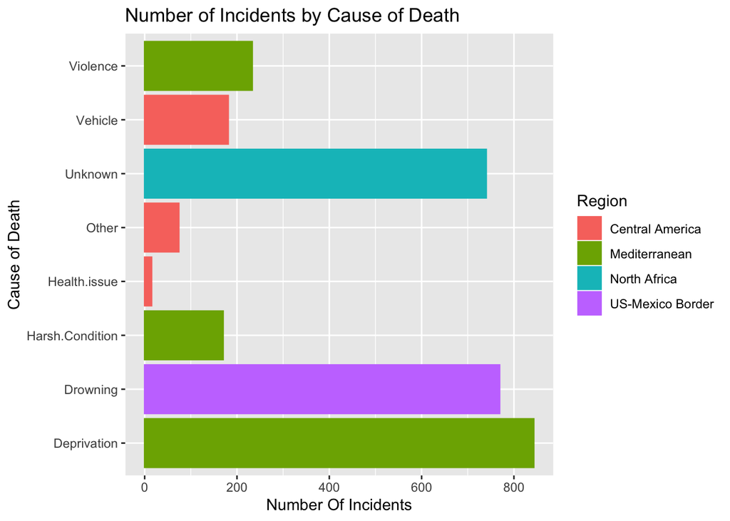

```r
Drowning <- migrations %>% filter(Drowning==1) %>% select(Region.of.Incident,Drowning)
Region.of.Incident <- NA
migrations2 <- migrations %>% select(Region.of.Incident, Drowning:Other)
Mediterranean <- data.frame(rep(NA,8))
dataFrame <- data.frame(rep(NA,8))

for(i in 2:9) {
        dataFrame[i-1,1] <- migrations2 %>% filter(migrations2[,i] == 1 & Region.of.Incident =="Mediterranean") %>% count()
}
for(i in 2:9) {
        dataFrame[i-1,2] <- migrations2 %>% filter(migrations2[,i] == 1 & Region.of.Incident =="US-Mexico Border") %>% count()
}
for(i in 2:9) {
        dataFrame[i-1,3] <- migrations2 %>% filter(migrations2[,i] == 1 & Region.of.Incident =="North Africa") %>% count()
}
for(i in 2:9) {
        dataFrame[i-1,4] <- migrations2 %>% filter(migrations2[,i] == 1 & Region.of.Incident =="Sub-Saharan Africa") %>% count()
}
for(i in 2:9) {
        dataFrame[i-1,5] <- migrations2 %>% filter(migrations2[,i] == 1 & Region.of.Incident =="Central America") %>% count()
}
colnames(dataFrame)[1]="US-Mexico Border"
colnames(dataFrame)[2]="North Africa"
colnames(dataFrame)[3]="Mediterranean"
colnames(dataFrame)[4]="Sub-Saharan Africa"
colnames(dataFrame)[5]="Central America"

rowMax <- function(data) apply(data, 1, max)
newdata <- data.frame(rep(NA,8))
newdata$`Region` <- colnames(dataFrame)[apply(dataFrame,1,which.max)]
newdata$`Number Of Incidents` <- rowMax(dataFrame)
colnames(newdata)[1] = "Cause of Death"

for (i in 2:9) {
    newdata[i-1,1] <- colnames(migrations2)[i]
}
ggplot(newdata, aes(y=`Number Of Incidents`, x=`Cause of Death`, color=Region, fill=Region)) +
    geom_bar(stat="identity") + coord_flip() + ggtitle("Number of Incidents by Cause of Death") + theme_update(plot.title = element_text(hjust = 0.5))
```

**2. What is the percentage of men, women, and children dying from each cause of death?**

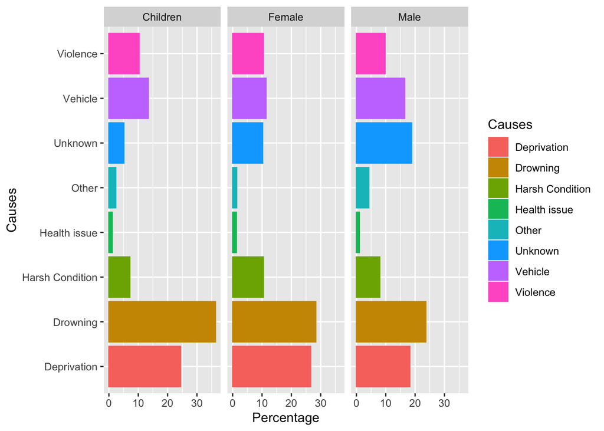

```r
childTemp <- migrations %>% select(c(11,12, 22:29)) %>% na.omit(childTemp)
childDrown <- sum(childTemp$Drowning)
childDep <- sum(childTemp$Deprivation)
childUnk <- sum(childTemp$Unknown)
childViol <- sum(childTemp$Violence)
childHarsh <- sum(childTemp$`Harsh.Condition`)
childVeh <- sum(childTemp$Vehicle)
childHealth <- sum(childTemp$`Health.issue`)
childOther <- sum(childTemp$`Other`)
femTemp <- migrations %>% select(c(9,13, 22:29)) %>% na.omit(femTemp)
femDrown <- sum(femTemp$Drowning)
femDep <- sum(femTemp$Deprivation)
femUnk <- sum(femTemp$Unknown)
femViol <- sum(femTemp$Violence)
femHarsh <- sum(femTemp$`Harsh.Condition`)
femVeh <- sum(femTemp$Vehicle)
femHealth <- sum(femTemp$`Health.issue`)
femOther <- sum(femTemp$`Other`)
maleTemp <- migrations %>% select(c(10,13, 22:29)) %>% na.omit(maleTemp)
maleDrown <- sum(maleTemp$Drowning)
maleDep <- sum(maleTemp$Deprivation)
maleUnk <- sum(maleTemp$Unknown)
maleViol <- sum(maleTemp$Violence)
maleHarsh <- sum(maleTemp$`Harsh.Condition`)
maleVeh <- sum(maleTemp$Vehicle)
maleHealth <- sum(maleTemp$`Health.issue`)
maleOther <- sum(maleTemp$`Other`)
df <- data.frame("Children"=c(265,178,37,75,52,98,8,17), "Male"=c(717,552,570,297,241,498,30,128), "Female"=c(289,271,104,106,107,116,13,14))
sumChild = sum(265,178,37,75,52,98,8,17)
sumFem = sum(717,552,570,297,241,498,30,128)
sumMale= sum(289,271,104,106,107,116,13,14)
percent <- data.frame(rep(NA,8))

for(i in 1:8) {
    percent[i,1] <- round((df[i,1]/sumChild *100),2)
}
for(i in 1:8) {
    percent[i,2] <- round((df[i,2]/sumFem *100),2)
}
for(i in 1:8) {
    percent[i,3] <- round((df[i,3]/sumMale *100),2)
}

colnames(percent)[1] <- "Children"
colnames(percent)[2] <- "Male"
colnames(percent)[3] <- "Female"

Percentage <- NA
Causes=c(rep("Drowning") , rep("Deprivation") , rep("Unknown") , rep("Violence"),rep("Harsh Condition") , rep("Vehicle") , rep("Health issue") , rep("Other"))
Gender=c(rep("Children", 8), rep("Male", 8), rep("Female", 8))

for (i in 1:8) {
    Percentage[i] <- percent[i,1]
}
for (i in 1:8) {
    Percentage[i+8] <- percent[i,2]
}
for (i in 1:8) {
    Percentage[i+16] <- percent[i,3]
}
graphData=data.frame(Gender,Causes,Percentage)
ggplot(graphData, aes(y=as.numeric(Percentage), x=Causes, color=Causes, fill=Causes)) +
    geom_bar(stat="identity") + coord_flip() + ylab("Percentage") +
    facet_wrap(~Gender)
```

### **Interpreter: Kevin Su**

**1. What is the distribution of source quality in northern America year-over-year?**

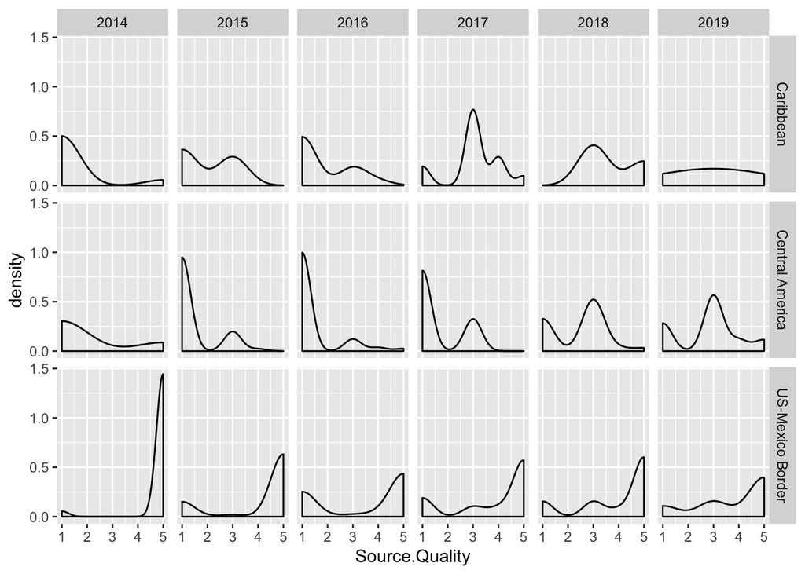

```r
migrations %>%
  filter(Region.of.Incident %in% c("Central America","Caribbean","US-Mexico Border")) %>%
  ggplot() + geom_density(aes(Source.Quality))+
  facet_grid(Region.of.Incident~Reported.Year)
```

**2. How did the proportion of men, women, and children missing or dead in northern America change year-over-year?**

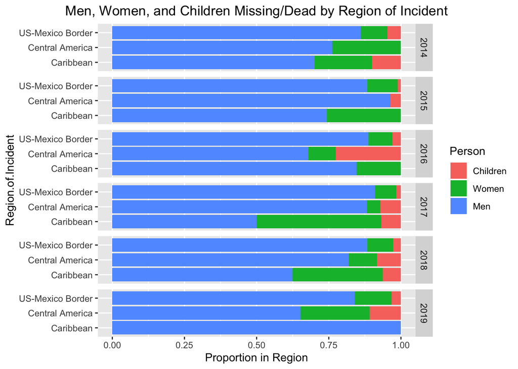

```r
migrations %>%
  filter(Region.of.Incident %in% c("US-Mexico Border","Caribbean","Central America")) %>%
  select(Region.of.Incident,Reported.Year,Number.of.Children,Number.of.Females,Number.of.Males) %>%
  arrange(Region.of.Incident,Reported.Year) %>%
  gather(Number.of.Females,Number.of.Males,Number.of.Children,key="Person",value="Number Missing/Dead") %>%
  mutate(Person=fct_recode(Person,Women="Number.of.Females",
                            Men="Number.of.Males",
                            Children="Number.of.Children"
                            )) %>%
  group_by(Reported.Year,Region.of.Incident,Person) %>%
  summarize(number=sum(`Number Missing/Dead`,na.rm=T)) %>%
  mutate(prop=number/sum(number)) %>%
  arrange(Region.of.Incident) %>%
  ggplot() + geom_col(aes(x=Region.of.Incident,y=prop,fill=Person)) +
  ggtitle("Men, Women, and Children Missing/Dead by Region of Incident") + ylab("Proportion in Region") +  coord_flip() + facet_grid(Reported.Year~.)
```

### **Orator: Polly Bridges**

**1. How has the number of missing migrations in the Mediterranean changed before and after the beginning of the Syrian refugee crisis?**

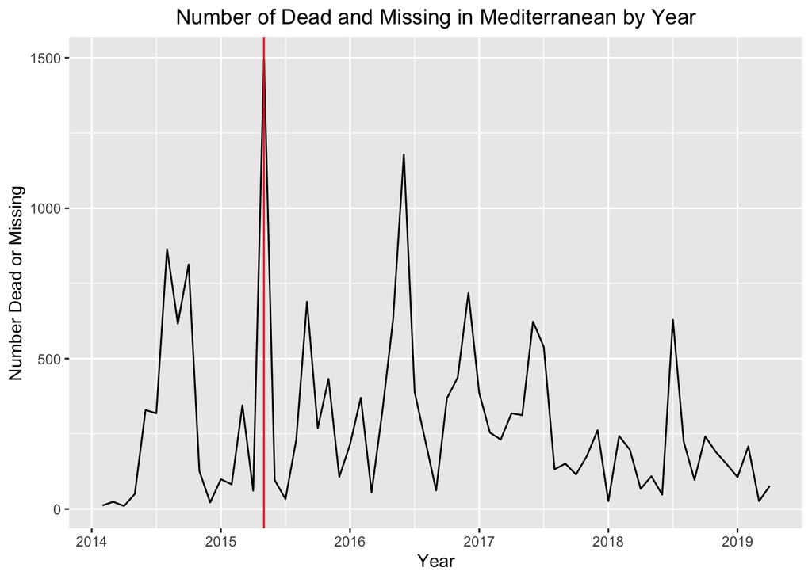

```r
med <-
  migrations %>%
  filter(Region.of.Incident == "Mediterranean") %>%
  mutate(Reported.Date = as.Date.character(Reported.Date, format = "%Y-%m-%d"),
         Reported.Month.Dbl = (lubridate::month(Reported.Date))/12
         ) %>%
  group_by(Reported.Year, Reported.Month.Dbl) %>%
  summarise(
    Total.Dead.and.Missing = sum(Total.Dead.and.Missing)
    ) %>%
  mutate(New.Date=Reported.Year+Reported.Month.Dbl)

med.plot <-
  ggplot(data = med, mapping = aes(x= New.Date,y = Total.Dead.and.Missing)) + xlab("Year") + ggtitle("Number of Dead and Missing in Mediterranean by Year") + ylab("Number Dead or Missing") + theme_update(plot.title = element_text(hjust = 0.5)) +
  geom_line() +
  geom_vline(aes(xintercept = 6046/3), color = "red")

med.plot
```

**2. What the number of missing and dead by region year-over-year?**

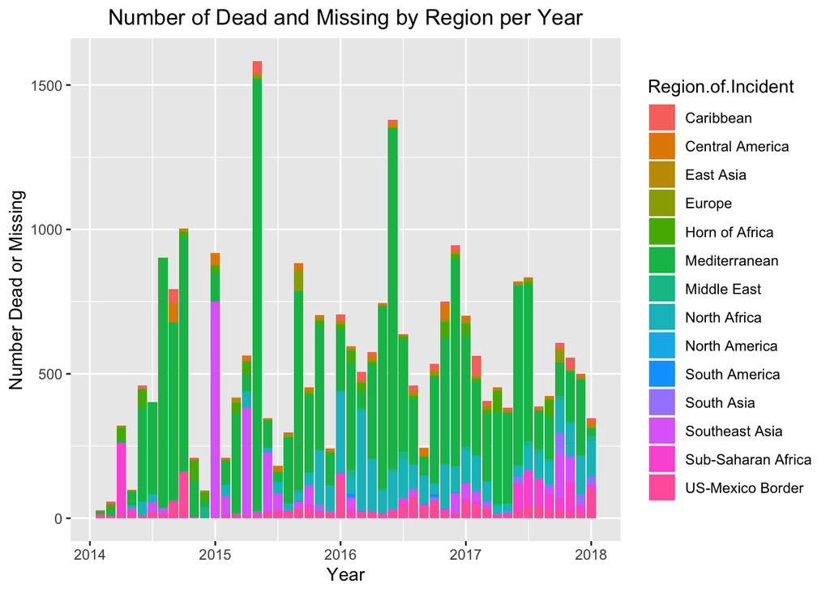

```r
all.regions <- migrations %>%
  mutate(Reported.Date = as.Date.character(Reported.Date, format = ("%Y-%m-%d")),
     Reported.Month.Dbl = (lubridate::month(Reported.Date))/12
     ) %>%
  group_by(Region.of.Incident,Reported.Year, Reported.Month.Dbl) %>%
  summarise(
    Total.Dead.and.Missing = sum(Total.Dead.and.Missing)
    ) %>%

  # Arrange Data Chronologically
  mutate(New.Date=Reported.Year+Reported.Month.Dbl) %>%
filter((New.Date >= 2014) & (New.Date <= 2018))

ggplot(data = all.regions, mapping = aes(x= New.Date,y = Total.Dead.and.Missing)) +
  geom_col(aes( fill = Region.of.Incident)) + ggtitle("Number of Dead and Missing by Region per Year") + ylab("Number Dead or Missing") + xlab("Year") + theme_update(plot.title = element_text(hjust = 0.5))
```

### **Orator: Thien Pham**

**1.Is there a difference in mean source quality between different locations where migrants have been found?**

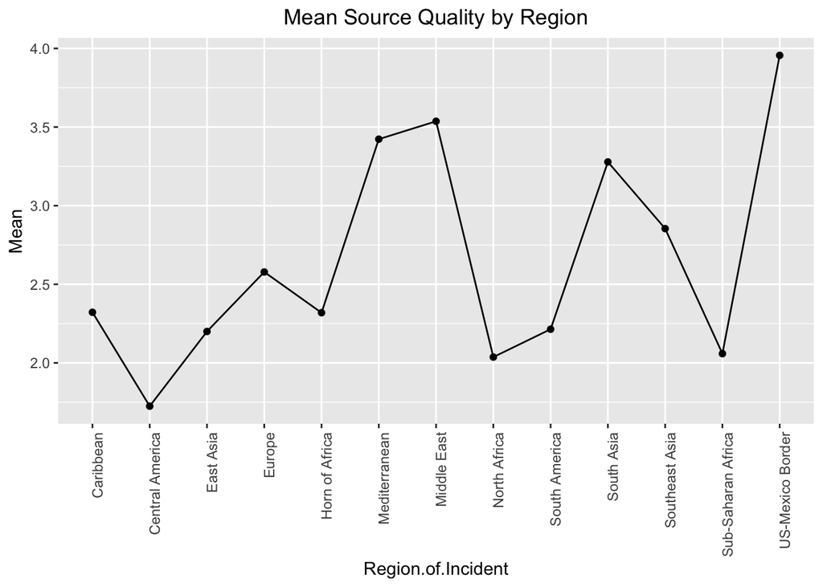

```r
myData_filtered <- migrations %>%
  filter(Region.of.Incident != "North America") %>%
  filter(Region.of.Incident != "Central Asia") %>%
  group_by(Region.of.Incident) %>%
  summarize(mean=mean(Source.Quality))

p <- ggplot(myData_filtered, aes(x = Region.of.Incident, y = mean,group=1)) + geom_point() +geom_line() + theme(axis.text.x = element_text(angle=90,hjust=1)) + ylab("Mean") + ggtitle("Mean Source Quality by Region")
p
```

**2. Among the most typical cause of Deaths, how is the number of dead and and missing related for US-Mexico Border, Caribbean, and Central America?**

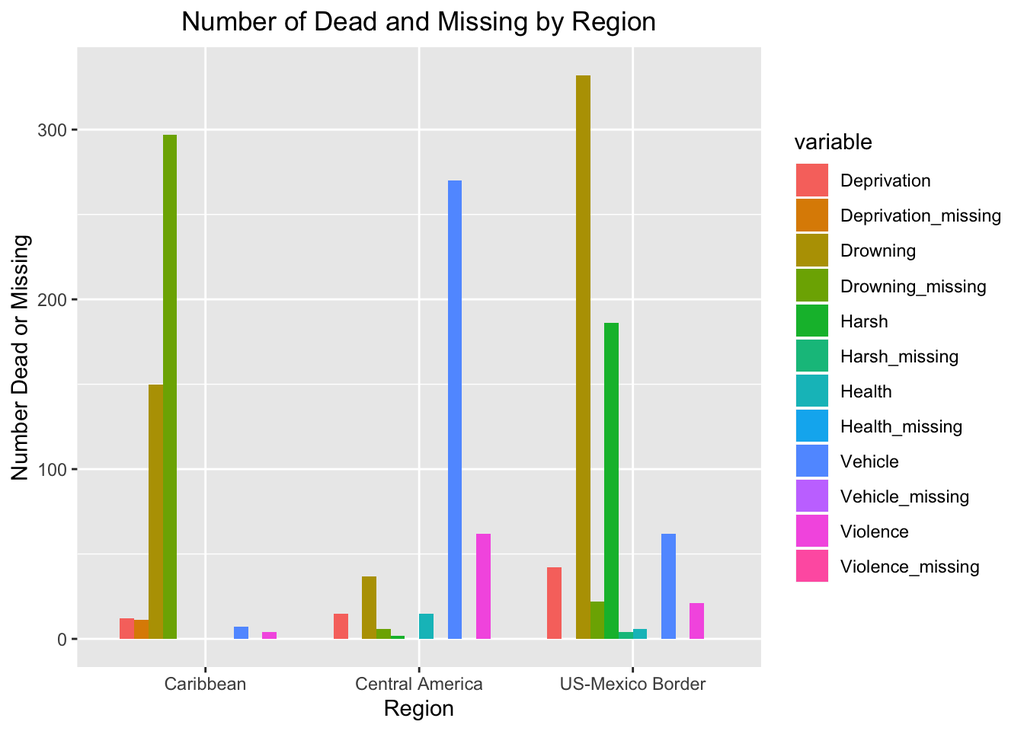

```r
sum <- migrations %>%
  select(c("Region.of.Incident", "Number.Dead",
                              "Minimum.Estimated.Number.of.Missing",
                              "Total.Dead.and.Missing",
                              "Drowning",
                              "Deprivation",
                              "Unknown",
                              "Violence",
                              "Harsh.Condition",
                              "Vehicle",
                              "Health.issue",
                              "Other",
                              "season",
                              "Reported.Year",
                              "Source.Quality" ))
sum <- filter(sum, Region.of.Incident %in% c("US-Mexico Border", "Caribbean", "Central America"))

sum$TotalDrowning = NA
sum$TotalDrowning <- sum$Number.Dead*sum$Drowning

sum$MissingDrowning = NA
sum$MissingDrowning <- sum$Minimum.Estimated.Number.of.Missing*sum$Drowning

sum$TotalDeprivation = NA
sum$TotalDeprivation <- sum$Number.Dead*sum$Deprivation


sum$MissingDeprivation = NA
sum$MissingDeprivation <- sum$Minimum.Estimated.Number.of.Missing*sum$Deprivation

sum$TotalUnknown = NA
sum$TotalUnknown <- sum$Number.Dead*sum$Unknown


sum$MissingUnknown= NA
sum$MissingUnknown <- sum$Minimum.Estimated.Number.of.Missing*sum$Unknown

sum$TotalViolence = NA
sum$TotalViolence <- sum$Number.Dead*sum$Violence


sum$MissingViolence= NA
sum$MissingViolence <- sum$Minimum.Estimated.Number.of.Missing*sum$Violence

sum$TotalHarsh = NA
sum$TotalHarsh <- sum$Number.Dead*sum$Harsh.Condition

sum$MissingHarsh= NA
sum$MissingHarsh <- sum$Minimum.Estimated.Number.of.Missing*sum$Harsh.Condition

sum$TotaVehicle = NA
sum$TotalVehicle <- sum$Number.Dead*sum$Vehicle

sum$MissingVehicle = NA
sum$MissingVehicle <- sum$Minimum.Estimated.Number.of.Missing*sum$Vehicle

sum$TotalHealth = NA
sum$TotalHealth <- sum$Number.Dead*sum$Health.issue

sum$MissingHealth  = NA
sum$MissingHealth <- sum$Minimum.Estimated.Number.of.Missing*sum$Health.issue

sum$TotalOther = NA
sum$TotalOther <- sum$Number.Dead*sum$Other

sum$MissingOther  = NA
sum$MissingOther <- sum$Minimum.Estimated.Number.of.Missing*sum$Other

nameTotal <- c("TotalDrowning","TotalDeprivation","TotalUnknown", "TotalViolence", "TotalHarsh", "TotalVehicle", "TotalHealth", "TotalOther")

missTotal <- c(sum(sum$MissingDrowning, na.rm = TRUE),
             sum(sum$MissingDeprivation, na.rm = TRUE),
             sum(sum$MissingUnknown, na.rm = TRUE),
             sum(sum$MissingViolence, na.rm = TRUE),
             sum(sum$MissingHarsh, na.rm = TRUE),
             sum(sum$MissingVehicle, na.rm = TRUE),
            sum(sum$MissingHealth, na.rm = TRUE),
            sum(sum$MissingOther, na.rm = TRUE))

deathTotal <- c(sum(sum$TotalDrowning, na.rm = TRUE),
             sum(sum$TotalDeprivation, na.rm = TRUE),
             sum(sum$TotalUnknown, na.rm = TRUE),
             sum(sum$TotalViolence, na.rm = TRUE),
             sum(sum$TotalHarsh, na.rm = TRUE),
             sum(sum$TotalVehicle, na.rm = TRUE),
            sum(sum$TotalHealth, na.rm = TRUE),
            sum(sum$TotalOther, na.rm = TRUE))

death <- data.frame(nameTotal, deathTotal, missTotal)
death <- death %>%
  arrange(desc(deathTotal, missTotal))

df2 <- melt(death, id.vars = 'nameTotal')

byLocation <- aggregate(cbind(sum$TotalDrowning,
                sum$TotalDeprivation,
                sum$TotalUnknown,
                sum$TotalHarsh,
                sum$TotalHealth,
                sum$TotalOther,
                sum$TotalVehicle,
                sum$TotalViolence), by=list(Category= sum$Region.of.Incident), FUN=sum, na.rm = T)

DeathbyLocation <- setNames(byLocation, c("Region","Drowning","Deprivation","Unknown",
                                     "Harsh", "Health", "Other",
                                     "Vehicle", "Violence"))

byMissing <- aggregate(cbind(sum$MissingDrowning,
                sum$MissingDeprivation,
                sum$MissingUnknown,
                sum$MissingHarsh,
                sum$MissingHealth,
                sum$MissingOther,
                sum$MissingVehicle,
                sum$MissingViolence), by=list(Category= sum$Region.of.Incident), FUN=sum, na.rm = T)

DeathByMissing <- setNames(byMissing, c("Region", "Drowning_missing","Deprivation_missing","Unknown_missing",
                                     "Harsh_missing", "Health_missing", "Other_missing",
                                     "Vehicle_missing", "Violence_missing"))


missAndDeath <- inner_join(DeathbyLocation, DeathByMissing, by = 'Region')
missAndDeath <- missAndDeath[ ,order(names(missAndDeath))]
missAndDeath <- select(missAndDeath, Region, everything())


df3 <- missAndDeath %>%
     select(-c(contains("Unknown"), contains("Other"))) %>%
     melt(id.vars = 'Region')
df3 <- filter(df3, Region %in% c("US-Mexico Border", "Caribbean", "Central America"))
ggplot(df3, aes(x= Region, y=value, fill=variable)) +
    geom_bar(stat='identity', position='dodge', width = 0.8) +
    ggtitle("Number of Dead and Missing by Region") + ylab("Number Dead or Missing") + theme_update(plot.title = element_text(hjust = 0.5))
```

### **Deliverer: Ben Caldwell**

**1. After Trump’s inaugaration (Jan. 2017), what does the distribution of number of dead by each cause of death look like at the U.S.-Mexico border?**

Donald Trump entered office in January of 2017. He was quick to implement a myriad of immigration policies, which has had an observable impact on migration trends, especially along the U.S.-Mexico border.

In terms of border security for the U.S., President Trump ordered the Department of Defense to deploy members of the National Guard to the southern border on April 4, 2018. He thereafter, implemented a series of policies restricting immigration into the United States, particularly from Mexico and Central America by way of the U.S.-Mexico border.

The number of incidents spiked shortly after Donald Trump assumed office at the start of 2017 and started implementing immigration policies. For example, the number of reported incidents jumped by 92 (roughly 11.5%) from the spring of 2018 – when harsher immigration policies went into effect – to the fall of 2018. Furthermore, the region of incident is greatest at the U.S.-Mexico border, accounting for 25% of all incidents globally – 1337 number of incidents.

Additionally, it should be noted that 3005 of all reported incidents occurred after Donald Trump took office. This is roughly 56.3% of all reported incidents, and reporting began in January of 2014.

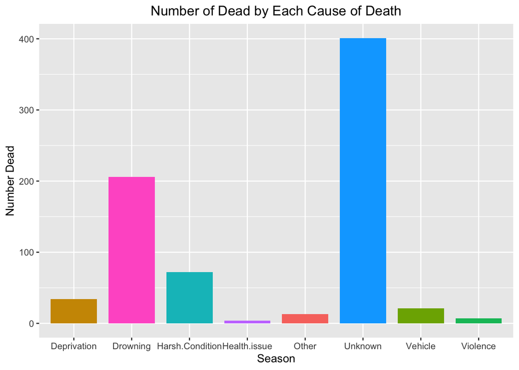

```r
migrations %>%
  filter(Region.of.Incident=="US-Mexico Border",post_trump==1) %>%
  gather(Drowning:Other,key="Cause of Death",value="T/F") %>%
  group_by(`Cause of Death`) %>%
  summarize(count=sum(`T/F`)) %>%
  arrange(desc(count)) %>%
  ggplot + geom_col(aes(x=`Cause of Death`,y=count, fill=rainbow(8), width=.8)) +
  ylab("Number Dead")+xlab("Season") + theme_update(plot.title = element_text(hjust = 0.5))+ ggtitle("Number of Dead by Each Cause of Death") + theme(legend.position = "none")
```

**2. In which seasons are most migrants found missing or dead?**

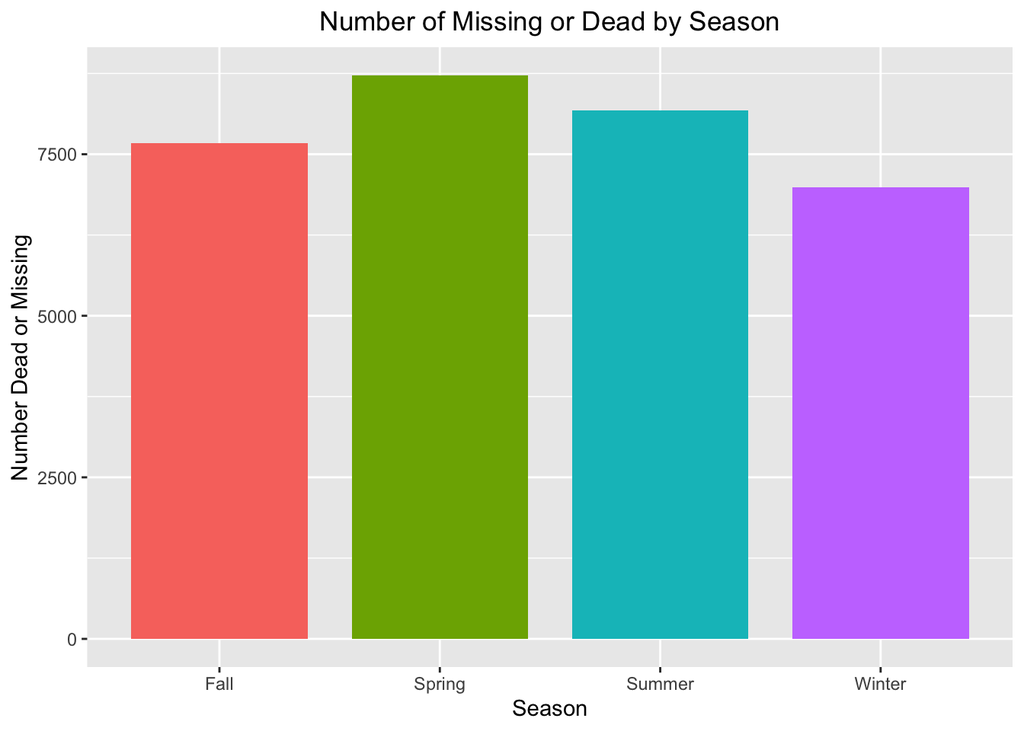

```r
migrations %>%
  group_by(season) %>%
  summarize(n=sum(Total.Dead.and.Missing)) %>%
  ggplot() + geom_col(aes(x=season,y=n, stat = "identity", fill=season, width=0.8)) + theme_update(plot.title = element_text(hjust = 0.5)) + ggtitle("Number of Missing or Dead by Season")+ylab("Number Dead or Missing")+xlab("Season") + theme(legend.position = "none")
```

## Follow-up Questions

### **New Questions Based Off Initial Investigation**

- Question 1: What is the number of migrants predicted to be dead or missing in the Mediterranean up to 2024?
- Question 2: Is it more likely for a man, woman, or child by way of the U.S.-Mexico border, Caribbean, and Central America to die from drowning?
- Question 3: Have there been more deaths from migration in the Western Hemisphere or Eastern Hemisphere (using a heat map)?
- Question 4: Does source quality and cause of death affect the number of dead? If so, how?

*GIVE WHAT 2 QUESTIONS YOU ATTEMPTED TO INVESTIGATE FURTHER IN COMPLETE SENTENCES (Example: Our group decided to investigate Q2 and Q4 in further detail.)* *SHOW AT LEAST 2 TABLES OR FIGURES BELOW THAT EXPLORE ANSWERS FOR THE QUESTIONS YOU ARE INVESTIGATING FURTHER.*

Our group wanted to delve into and explore *Question 1* and *Question 4* in greater detail. The following two models help to illustrate and answer those two questions. **Model 1** pertains to *Question 4* and **Model 2** pertains to *Question 1*.

### **Model 1**

```r
set.seed(2222222)


TEST.LOCATIONS=sample(x=unique(migrations$Region.of.Incident),size=6,replace=F)
TEST.LOCATIONS
```

```
## [1] "Caribbean"          "East Asia"          "Europe"
## [4] "North America"      "Central Asia"       "Sub-Saharan Africa"
```

```r
TRAIN = anti_join(migrations,tibble(Region.of.Incident=TEST.LOCATIONS),by="Region.of.Incident")
TEST = semi_join(migrations,tibble(Region.of.Incident=TEST.LOCATIONS),by="Region.of.Incident")



fit1 <- glm(Number.Dead ~ Unknown + Other + Drowning+ Health.issue + Deprivation+Unknown+Violence+Harsh.Condition+Vehicle+ Source.Quality , data=migrations, family= quasipoisson())



summary(fit1)
```

```
##
## Call:
## glm(formula = Number.Dead ~ Unknown + Other + Drowning + Health.issue +
##     Deprivation + Unknown + Violence + Harsh.Condition + Vehicle +
##     Source.Quality, family = quasipoisson(), data = migrations)
##
## Deviance Residuals:
##    Min      1Q  Median      3Q     Max
## -3.687  -1.275  -0.642  -0.237  74.626
##
## Coefficients:
##                 Estimate Std. Error t value Pr(>|t|)
## (Intercept)      0.79991    0.23602   3.389 0.000706 ***
## Unknown         -0.70441    0.24864  -2.833 0.004628 **
## Other            0.81136    0.22651   3.582 0.000344 ***
## Drowning         0.72870    0.21520   3.386 0.000714 ***
## Health.issue    -0.63049    0.69616  -0.906 0.365157
## Deprivation      0.05863    0.20584   0.285 0.775787
## Violence        -0.13777    0.22896  -0.602 0.547381
## Harsh.Condition -0.29829    0.22794  -1.309 0.190704
## Vehicle         -0.33349    0.22171  -1.504 0.132607
## Source.Quality   0.09697    0.03378   2.871 0.004109 **
## ---
## Signif. codes:  0 '***' 0.001 '**' 0.01 '*' 0.05 '.' 0.1 ' ' 1
##
## (Dispersion parameter for quasipoisson family taken to be 31.09997)
##
##     Null deviance: 38100  on 5141  degrees of freedom
## Residual deviance: 33283  on 5132  degrees of freedom
##   (191 observations deleted due to missingness)
## AIC: NA
##
## Number of Fisher Scoring iterations: 6
```

```r
fit2 <- glm(Number.Dead ~ Deprivation+Unknown+Violence+Harsh.Condition+Vehicle+ Source.Quality , data=TRAIN, family= quasipoisson())

fit3<- glm(Number.Dead ~ Unknown+Violence+ Vehicle+ Source.Quality + Harsh.Condition*Deprivation , data= TRAIN, family= quasipoisson())

Full=lm(Number.Dead ~ Unknown+Violence+ Vehicle+ Source.Quality + Harsh.Condition*Deprivation , data= TRAIN)
MSE=(summary(Full)$sigma)^2
none=lm(Number.Dead~1, data=TRAIN)
step(none, scope=list(upper=Full),scale=MSE)
```

```
## Start:  AIC=67.61
## Number.Dead ~ 1
##
##                   Df Sum of Sq    RSS     Cp
## + Unknown          1    3867.1 866605 49.878
## + Vehicle          1     721.6 869750 65.928
## + Harsh.Condition  1     491.9 869980 67.100
## + Deprivation      1     392.8 870079 67.605
## <none>                         870472 67.610
## + Violence         1     388.8 870083 67.626
## + Source.Quality   1     126.4 870346 68.965
##
## Step:  AIC=49.88
## Number.Dead ~ Unknown
##
##                   Df Sum of Sq    RSS     Cp
## + Deprivation      1    1767.2 864838 42.861
## + Source.Quality   1    1762.1 864843 42.887
## + Vehicle          1    1554.0 865051 43.949
## + Harsh.Condition  1    1088.2 865517 46.325
## + Violence         1    1021.1 865584 46.668
## <none>                         866605 49.878
## - Unknown          1    3867.1 870472 67.610
##
## Step:  AIC=42.86
## Number.Dead ~ Unknown + Deprivation
##
##                   Df Sum of Sq    RSS     Cp
## + Vehicle          1    2674.6 862163 31.213
## + Violence         1    1442.8 863395 37.499
## + Harsh.Condition  1    1088.1 863750 39.308
## + Source.Quality   1    1073.9 863764 39.381
## <none>                         864838 42.861
## - Deprivation      1    1767.2 866605 49.878
## - Unknown          1    5241.5 870079 67.605
##
## Step:  AIC=31.21
## Number.Dead ~ Unknown + Deprivation + Vehicle
##
##                   Df Sum of Sq    RSS     Cp
```

[output cut: 41 more lines]

```
## - Violence                     1    3195.7 859831 23.314
## - Vehicle                      1    4775.6 861411 31.376
## - Unknown                      1   10964.2 867600 62.953
##
## Step:  AIC=8
## Number.Dead ~ Unknown + Deprivation + Vehicle + Violence + Harsh.Condition +
##     Source.Quality + Deprivation:Harsh.Condition
##
##                               Df Sum of Sq    RSS     Cp
## <none>                                     856046  8.000
## - Source.Quality               1     589.5 856635  9.008
## - Deprivation:Harsh.Condition  1    1228.8 857275 12.270
## - Violence                     1    2827.4 858873 20.427
## - Vehicle                      1    4081.4 860127 26.825
## - Unknown                      1   11499.1 867545 64.674
```

```
##
## Call:
## lm(formula = Number.Dead ~ Unknown + Deprivation + Vehicle +
##     Violence + Harsh.Condition + Source.Quality + Deprivation:Harsh.Condition,
##     data = TRAIN)
##
## Coefficients:
##                 (Intercept)                      Unknown
##                      5.1887                      -4.7687
##                 Deprivation                      Vehicle
##                     -2.6662                      -3.3557
##                    Violence              Harsh.Condition
##                     -2.7612                      -4.0468
##              Source.Quality  Deprivation:Harsh.Condition
##                      0.2952                       4.0794
```

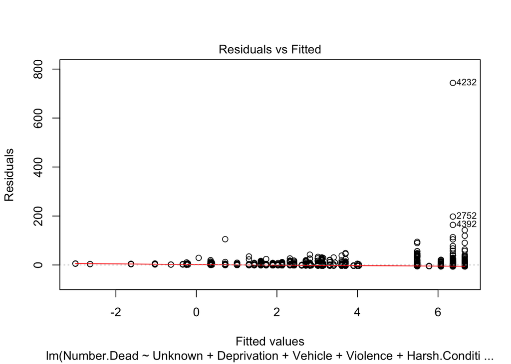

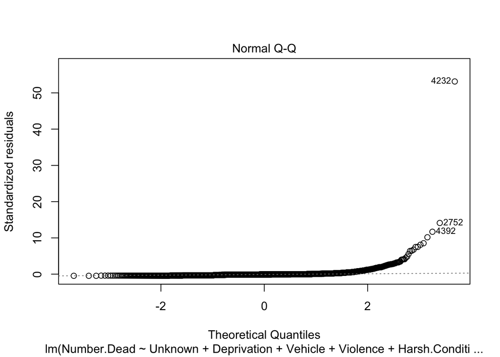

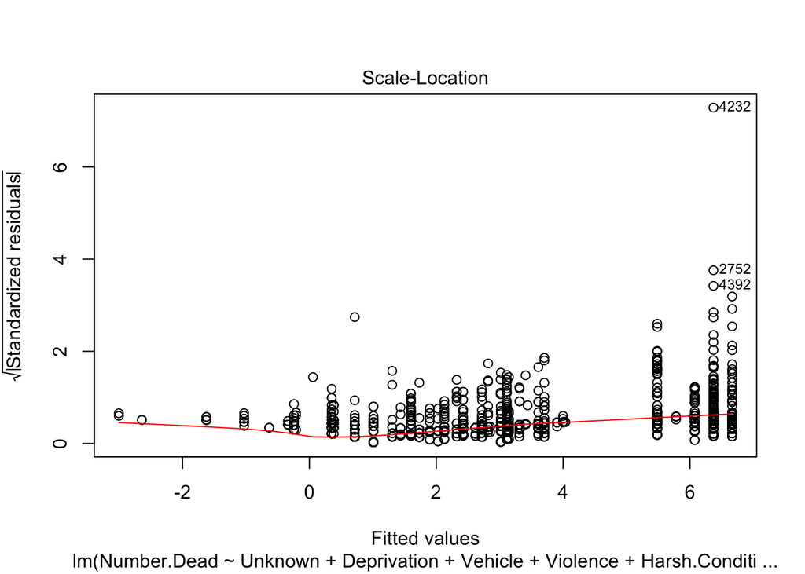

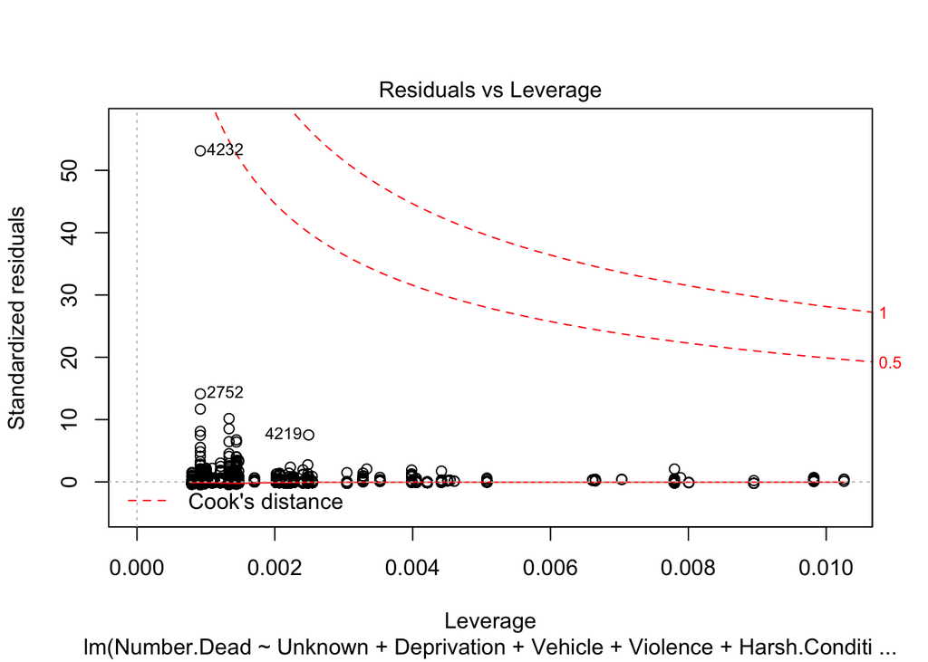

```r
fit4 <- lm(formula = Number.Dead ~ Unknown + Deprivation + Vehicle +  Violence + Harsh.Condition + Source.Quality + Deprivation:Harsh.Condition, data = TRAIN)
plot(fit4)
```

```r
predict_Dead <- predict(fit1, newdata = TEST, type = "response")
TEST$predict = NA
TEST$predict = predict_Dead
TEST
```

```
## # A tibble: 790 x 30
##    Region.of.Incid… Reported.Date Reported.Year Reported.Month Number.Dead
##    <chr>            <date>                <dbl> <chr>                <dbl>
##  1 Caribbean        2019-03-11             2019 Mar                      1
##  2 Europe           2019-03-08             2019 Mar                      1
##  3 Europe           2019-03-08             2019 Mar                      1
##  4 Europe           2019-02-24             2019 Feb                      2
##  5 Europe           2019-02-08             2019 Feb                      1
##  6 Europe           2019-02-07             2019 Feb                      1
##  7 Europe           2019-02-05             2019 Feb                      1
##  8 Europe           2019-02-03             2019 Feb                      1
##  9 Caribbean        2019-02-02             2019 Feb                     31
## 10 Europe           2019-01-11             2019 Jan                      1
## # … with 780 more rows, and 25 more variables:
## #   Minimum.Estimated.Number.of.Missing <dbl>,
## #   Total.Dead.and.Missing <dbl>, Number.of.Survivors <dbl>,
## #   Number.of.Females <dbl>, Number.of.Males <dbl>,
## #   Number.of.Children <dbl>, Cause.of.Death <chr>,
## #   Location.Description <chr>, Information.Source <chr>, Latitude <dbl>,
## #   Longitude <dbl>, Migration.Route <chr>, Source.Quality <dbl>,
## #   season <chr>, post_trump <dbl>, Reported.Month.Int <dbl>,
## #   Drowning <dbl>, Deprivation <dbl>, Unknown <dbl>, Violence <dbl>,
## #   Harsh.Condition <dbl>, Vehicle <dbl>, Health.issue <dbl>, Other <dbl>,
## #   predict <dbl>
```

```r
summary(fit1)
```

```
##
## Call:
## glm(formula = Number.Dead ~ Unknown + Other + Drowning + Health.issue +
##     Deprivation + Unknown + Violence + Harsh.Condition + Vehicle +
##     Source.Quality, family = quasipoisson(), data = migrations)
##
## Deviance Residuals:
##    Min      1Q  Median      3Q     Max
## -3.687  -1.275  -0.642  -0.237  74.626
##
## Coefficients:
##                 Estimate Std. Error t value Pr(>|t|)
## (Intercept)      0.79991    0.23602   3.389 0.000706 ***
## Unknown         -0.70441    0.24864  -2.833 0.004628 **
## Other            0.81136    0.22651   3.582 0.000344 ***
## Drowning         0.72870    0.21520   3.386 0.000714 ***
## Health.issue    -0.63049    0.69616  -0.906 0.365157
## Deprivation      0.05863    0.20584   0.285 0.775787
## Violence        -0.13777    0.22896  -0.602 0.547381
## Harsh.Condition -0.29829    0.22794  -1.309 0.190704
## Vehicle         -0.33349    0.22171  -1.504 0.132607
## Source.Quality   0.09697    0.03378   2.871 0.004109 **
## ---
## Signif. codes:  0 '***' 0.001 '**' 0.01 '*' 0.05 '.' 0.1 ' ' 1
##
## (Dispersion parameter for quasipoisson family taken to be 31.09997)
##
##     Null deviance: 38100  on 5141  degrees of freedom
## Residual deviance: 33283  on 5132  degrees of freedom
##   (191 observations deleted due to missingness)
## AIC: NA
##
## Number of Fisher Scoring iterations: 6
```

```r
summary(fit2)
```

```
##
## Call:
## glm(formula = Number.Dead ~ Deprivation + Unknown + Violence +
##     Harsh.Condition + Vehicle + Source.Quality, family = quasipoisson(),
##     data = TRAIN)
##
## Deviance Residuals:
##    Min      1Q  Median      3Q     Max
## -3.601  -1.435  -0.715  -0.270  75.097
##
## Coefficients:
##                 Estimate Std. Error t value Pr(>|t|)
## (Intercept)      1.57465    0.14076  11.187  < 2e-16 ***
## Deprivation     -0.56225    0.12730  -4.417 1.03e-05 ***
## Unknown         -1.38953    0.16572  -8.385  < 2e-16 ***
## Violence        -0.71858    0.18226  -3.942 8.19e-05 ***
## Harsh.Condition -0.79863    0.20761  -3.847 0.000121 ***
## Vehicle         -0.89275    0.18934  -4.715 2.49e-06 ***
## Source.Quality   0.07360    0.03742   1.967 0.049285 *
## ---
## Signif. codes:  0 '***' 0.001 '**' 0.01 '*' 0.05 '.' 0.1 ' ' 1
##
## (Dispersion parameter for quasipoisson family taken to be 34.47858)
##
##     Null deviance: 33710  on 4375  degrees of freedom
## Residual deviance: 29843  on 4369  degrees of freedom
##   (167 observations deleted due to missingness)
## AIC: NA
##
## Number of Fisher Scoring iterations: 6
```

```r
summary(fit3)
```

```
##
## Call:
## glm(formula = Number.Dead ~ Unknown + Violence + Vehicle + Source.Quality +
##     Harsh.Condition * Deprivation, family = quasipoisson(), data = TRAIN)
##
## Deviance Residuals:
##    Min      1Q  Median      3Q     Max
## -3.654  -1.342  -0.615  -0.331  74.806
##
## Coefficients:
##                             Estimate Std. Error t value Pr(>|t|)
## (Intercept)                  1.58354    0.13930  11.368  < 2e-16 ***
## Unknown                     -1.42029    0.16390  -8.666  < 2e-16 ***
## Violence                    -0.74016    0.18020  -4.107 4.07e-05 ***
## Vehicle                     -0.91175    0.18716  -4.871 1.15e-06 ***
## Source.Quality               0.07869    0.03710   2.121  0.03395 *
## Harsh.Condition             -1.13374    0.26501  -4.278 1.93e-05 ***
## Deprivation                 -0.64243    0.13132  -4.892 1.03e-06 ***
## Harsh.Condition:Deprivation  1.12433    0.41931   2.681  0.00736 **
## ---
## Signif. codes:  0 '***' 0.001 '**' 0.01 '*' 0.05 '.' 0.1 ' ' 1
##
## (Dispersion parameter for quasipoisson family taken to be 33.72009)
##
##     Null deviance: 33710  on 4375  degrees of freedom
## Residual deviance: 29622  on 4368  degrees of freedom
##   (167 observations deleted due to missingness)
## AIC: NA
##
## Number of Fisher Scoring iterations: 6
```

```r
summary(fit4)
```

```
##
## Call:
## lm(formula = Number.Dead ~ Unknown + Deprivation + Vehicle +
##     Violence + Harsh.Condition + Source.Quality + Deprivation:Harsh.Condition,
##     data = TRAIN)
##
## Residuals:
##    Min     1Q Median     3Q    Max
##  -6.37  -2.11  -1.11  -0.32 743.63
##
## Coefficients:
##                             Estimate Std. Error t value Pr(>|t|)
## (Intercept)                   5.1887     0.6579   7.887 3.88e-15 ***
## Unknown                      -4.7687     0.6226  -7.660 2.28e-14 ***
## Deprivation                  -2.6662     0.5924  -4.501 6.94e-06 ***
## Vehicle                      -3.3557     0.7353  -4.563 5.17e-06 ***
## Violence                     -2.7612     0.7270  -3.798 0.000148 ***
## Harsh.Condition              -4.0468     0.9648  -4.194 2.79e-05 ***
## Source.Quality                0.2952     0.1702   1.734 0.082923 .
## Deprivation:Harsh.Condition   4.0794     1.6291   2.504 0.012315 *
## ---
## Signif. codes:  0 '***' 0.001 '**' 0.01 '*' 0.05 '.' 0.1 ' ' 1
##
## Residual standard error: 14 on 4368 degrees of freedom
##   (167 observations deleted due to missingness)
## Multiple R-squared:  0.01657,    Adjusted R-squared:  0.015
## F-statistic: 10.52 on 7 and 4368 DF,  p-value: 3.586e-13
```

### **Model 2**

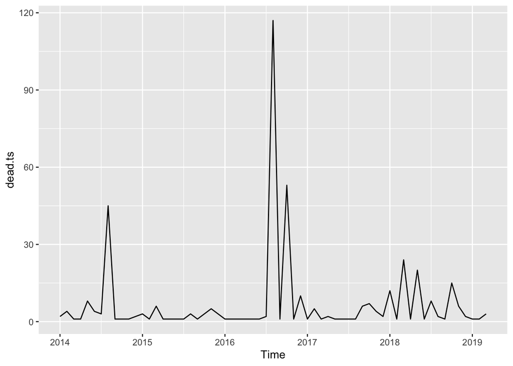

```r
mediterranean <- migrations %>%
  mutate(Reported.Date = as.Date(Reported.Date, format = "%Y-%b-%d")) %>%
  filter(Region.of.Incident == "Mediterranean")

set.seed(1)

dead.ts <- ts(mediterranean$Total.Dead.and.Missing, start = c(2014,1), end = c(2019,3), frequency = 12)

# Autoplot for Data Set
autoplot(dead.ts)
```

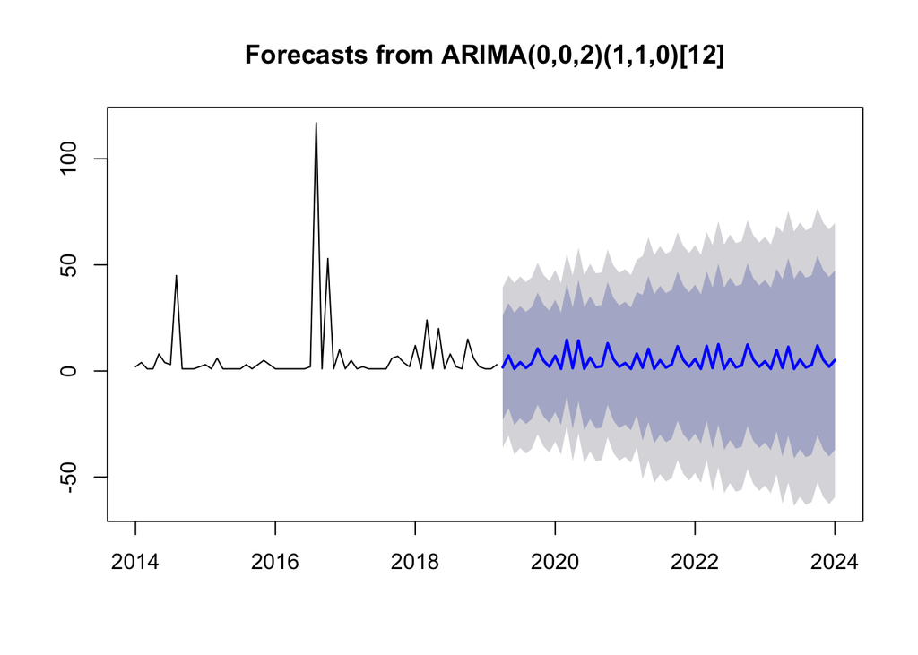

```r
train = dead.ts[1:350]
test = dead.ts[351:370]
arma_fit <- forecast::auto.arima(dead.ts, stepwise = FALSE, approximation = FALSE, D = 1)
arma_forecast <- forecast::forecast(arma_fit)

arimaModel_1 = arima(dead.ts, order = c(0,1,2), seasonal = c(0,1,2))
arimaModel_2 = arima(dead.ts, order = c(1,1,2), seasonal = c(1,1,2))
arimaModel_3 = arima(dead.ts, order = c(1,1,1), seasonal = c(1,1,1))

# Auto ARIMA
plot(forecast::forecast(arma_fit, h = 58))
lines(dead.ts[1:36])
```

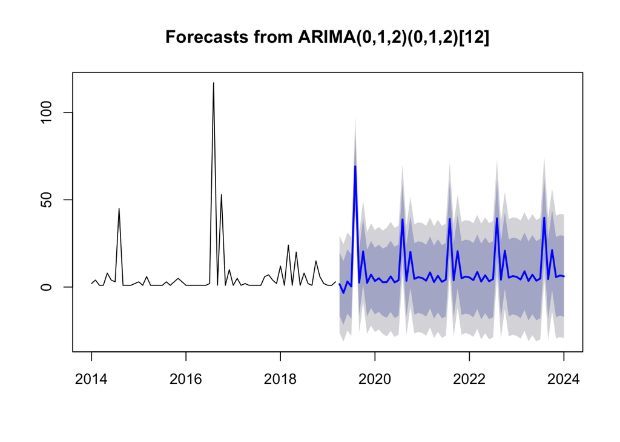

```r
# Manual ARIMA
plot(forecast::forecast(arimaModel_1, h = 58))
```

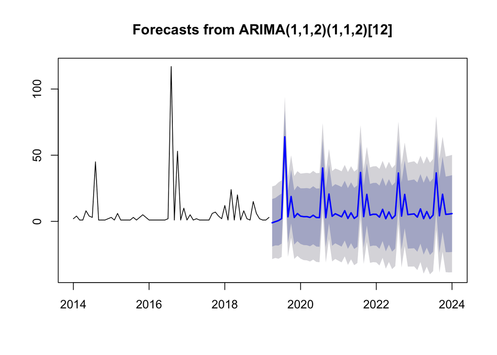

```r
plot(forecast::forecast(arimaModel_2, h = 58))
```

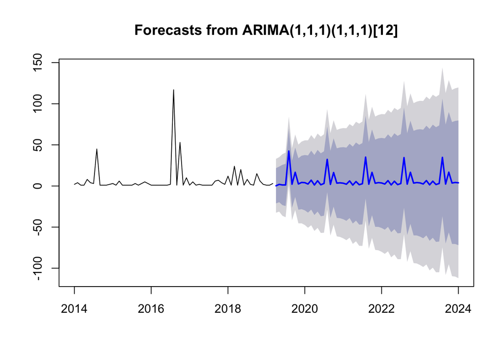

```r
plot(forecast::forecast(arimaModel_3, h = 58))
```

```r
summary(arma_fit)
```

```
## Series: dead.ts
## ARIMA(0,0,2)(1,1,0)[12]
##
## Coefficients:
##          ma1    ma2     sar1
##       0.0113  0.381  -0.5557
## s.e.  0.1298  0.125   0.0969
##
## sigma^2 estimated as 371.2:  log likelihood=-224.08
## AIC=456.15   AICc=457.02   BIC=463.88
##
## Training set error measures:
##                     ME     RMSE      MAE       MPE     MAPE    MASE
## Training set -0.151585 16.81795 6.575412 -199.3611 255.0508 0.60972
##                     ACF1
## Training set -0.02044416
```

```r
arimaModel_1;arimaModel_2;arimaModel_3
```

```
##
## Call:
## arima(x = dead.ts, order = c(0, 1, 2), seasonal = c(0, 1, 2))
##
## Coefficients:
##           ma1     ma2     sma1    sma2
##       -0.9276  0.0558  -1.8563  0.9952
## s.e.   0.1469  0.1242   0.8767  0.8885
##
## sigma^2 estimated as 131.9:  log likelihood = -218.65,  aic = 447.3
```

```
##
## Call:
## arima(x = dead.ts, order = c(1, 1, 2), seasonal = c(1, 1, 2))
##
## Coefficients:
##           ar1      ma1      ma2    sar1     sma1    sma2
##       -0.8845  -0.0673  -0.5602  0.1128  -1.8036  0.9998
## s.e.   0.1647   0.2165   0.2482  0.2443   0.6015  0.6042
##
## sigma^2 estimated as 141.6:  log likelihood = -216.61,  aic = 447.22
```

```
##
## Call:
## arima(x = dead.ts, order = c(1, 1, 1), seasonal = c(1, 1, 1))
##
## Coefficients:
##           ar1      ma1     sar1     sma1
##       -0.4552  -0.3981  -0.2547  -0.9999
## s.e.   0.2853   0.3925   0.1388   0.3159
##
## sigma^2 estimated as 229.4:  log likelihood = -219.67,  aic = 449.34
```

## **Summary**

*GIVE A 2 PARAGRAPH SUMMARY.*

*PARAGRAPH 1 SHOULD DESCRIBE WHAT YOU LEARNED ABOUT YOUR DATA FROM INVESTIGATING THE INITIAL QUESTIONS. DID YOU FIND ANYTHING UNUSUAL IN YOUR DATA? DID ANYTHING SURPRISE YOU? WHICH OF THE INITIAL QUESTIONS WERE HELPFUL IN LEADING YOU TO MORE QUESTIONS?*

### Paragraph 1

Firstly, and very importantly, we found that drowning was the top cause of death worldwide, regardless of gender. The greatest number of incidents occurred at the U.S.-Mexico border, North Africa, and the Mediterranean. It is important to note that more people were found dead than declared missing in every region around the world for every cause of death excluding drowning. Furthermore, we noticed there were some important periods of time over the course of the five years the data covers. Notably, shortly into 2015, there was a very sharp spike in the number of incidents – both dead and missing – in the Mediterranean. While we can not assume that the following two events are the reason for increased number of incidents, our findings are fitting. We observed an increased number of incidents in the Mediterranean at the start of 2015, and that may be attributed to the Syrian refugee crisis – where many Syrians migrated to Europe by way of the Mediterranean. Also, we observed an increase in the number of incidents at the start of 2018 at the U.S.-Mexico border. Somewhat similarly, this may be attributed policies put in place by U.S. president Donald Trump. The data pulled from incidents at the U.S.-Mexico border is relatively reliable because it has the highest source quality mean, but the data is not as reliable from Central America as its source quality is relatively low. Finally, we found that the majority of missing or dead migrants were men. Women accounted for the second largest percentage of missing migrants aside from children in Central America in 2016 and 2017. Besides these few exceptions, we observed that the data was relatively consistent.

*PARAGRAPH 2 SHOULD SUMMARIZE WHAT YOU LEARNED FROM INVESTIGATING THE FOLLOW-UP QUESTIONS. WHY ARE THESE FOLLOW-UP QUESTIONS INTERESTING FOR INVESTIGATION? DESCRIBE THE TABLES/FIGURES YOU USED TO EXPLORE ANSWERS TO THESE FOLLOW-UP QUESTIONS? WHAT DID YOU LEARN FROM THE TABLES/FIGURES REGARDING THE FOLLOW-UP QUESTIONS YOU PROPOSED?*

### Paragraph 2

We also wanted to dive further into how source quality and cause of death affects the total number of deaths among migrants. We put together a model – regression analysis – that would help us analyze various relationships between some of the variables in our dataset. Particularly, we wished to observe the residuals. With our initial model, we picked variables that might illustrate a relationship to the total number of deaths among migrants globally (response variable). While each model differed in its purpose, we effectively wanted to see which combination of predictors gave us the lowest Mallow’s Cp value – finding the set of predictors that best predict the response variable. With this, we observed that cause of death does have an impact on the total number of deaths among migrations globally.